# Genomics and Population Genetics Analysis

Author

Reva Shenwai

Published

July 24, 2026

```r
## Set up
knitr::opts_chunk$set(echo=TRUE)

# load packages
library(dplyr)
library(flextable)
library(metafor)
library(data.table)
library(purrr)
library(arrow)
library(ggplot2)
library(tidyverse)
library(susieR)
library(coloc)
library(patchwork)
library(glue)
library(httr)
library(jsonlite)
library(MendelianRandomization)

# table format defaults
set_flextable_defaults(font.size=10,
                       padding=6,
                       background.color="#EFEFEF",
                       text.align="center")
```

## Project

This report details a population genetics analysis based on a published GWAS meta-analysis study of circulating metabolic biomarkers from the Estonian and UK Biobanks, Tambets et al. (2026). The goal of my analysis was to assess genetic associations of **T2D** (Type 2 Diabetes) with two metabolic traits - **Total BCAA** (branched chain amino acids) and **Glucose** - within European populations.

Total BCAA captures the central finding of Tambets et al., while Glucose has been very well characterized as having a role in T2D pathophysiology and can serve as a positive control.

## Meta-analysis and harmonization

Biobank data is highly restricted and requires specialized permissions to access. In order to ensure data security and compliance, this analysis was based on publicly available GWAS summary statistics provided by Tambets et al. (2026) for Estonian Biobank (primarily European origin) and the European cohort from the UK Biobank.

GWAS summary statistics for the two cohorts were harmonized followed by IVW (inverse variance weighting) fixed-effect meta-analysis for each metabolic trait respectively. Since both cohorts were European, they were expected to have a single shared true effect for a given set of traits.

```r
## Converted large data files to parquet for efficient memory handling

## GWAS summary stats for Total BCAA and Glucose
# extract file names
gwas_stat_files <- list.files(path=paste0(getwd(),"/../data"),
                              pattern=".tsv.gz",
                              full.names=TRUE)
names(gwas_stat_files) <- sapply(gwas_stat_files,function(nm){
  nm <- unlist(unname(strsplit(nm,split="/")))[10]
  nm <- gsub(nm,pattern=".tsv.gz",replacement="")
  return(nm)
})

# convert tsv.gz to parquet
for (nm in names(gwas_stat_files)){
  message(paste("Converting:", nm))
  # select necessary columns only
  tmp.df <- data.table::fread(gwas_stat_files[[nm]],
                              select=c("chromosome","base_pair_location",
                                       "effect_allele","other_allele",
                                       "beta","standard_error",
                                       "effect_allele_frequency","info","rsid","n"))
  # write parquet
  arrow::write_parquet(tmp.df, paste0(getwd(),"/../data/",nm,".parquet"))
  # clear memory
  rm(tmp.df)
}

# T2D GWAS summary stats
# file path
t2d_file <- paste0(getwd(),"/../data/EUR_Metal_LDSC-CORR_Neff.v2.txt")
# convert to parquet
tmp.df <- data.table::fread(t2d_path,
                            select=c("Chromsome","Position","EffectAllele",
                                     "NonEffectAllele","Beta","SE","Pval","Neff"))
arrow::write_parquet(tmp.df, paste0(getwd(),"/../data/t2d.parquet"))
rm(tmp.df)
```

```r
## IVW fixed-effect meta-analysis using ESTBB + UKBB_EUR
## Traits: Total BCAA, Glucose; Disease: T2D

# fxn to lazy read per chromosome + QC + generate key for merging ESTBB + UKBB_EUR
read_chr <- function(parquet_path, chr){
  # open lazily, apply filters, collect data
  chr.df <- arrow::open_dataset(parquet_path) %>%
    dplyr::filter(chromosome == chr,
                  info >= 0.6,
                  standard_error > 0,
                  effect_allele_frequency > 0.001,
                  effect_allele_frequency < 0.999) %>%
    dplyr::collect()
  # generate unique allele key for merging cohorts
  chr.df$key <- paste(chr.df$chromosome,
                      chr.df$base_pair_location,
                      pmin(chr.df$effect_allele, chr.df$other_allele),
                      pmax(chr.df$effect_allele, chr.df$other_allele),
                      sep=":")
  # return data collected from chromosome
  return(chr.df)
}

# harmonize + meta-analyze both cohorts for one trait
meta_trait <- function(est_parquet, ukb_parquet){
  # loop through chromosomes, bind results
  meta.df <- purrr::map_dfr(1:23, function(chr){
    message(paste("  chromosome", chr))
    # read per chr from each cohort
    est.df <- read_chr(est_parquet, chr)
    ukb.df <- read_chr(ukb_parquet, chr)
    # merge cohorts on allele key
    chr.df <- dplyr::inner_join(est.df, ukb.df,
                                by="key",
                                suffix=c("_est","_ukb"))
    # clear memory
    rm(est.df, ukb.df)
    # harmonize orientation to ESTBB effect allele
    flip <- chr.df$effect_allele_est != chr.df$effect_allele_ukb
    chr.df$beta_ukb[flip] <- -chr.df$beta_ukb[flip]
    chr.df$effect_allele_frequency_ukb[flip] <- 1 - chr.df$effect_allele_frequency_ukb[flip]
    # IVW fixed-effect pooling
    chr.df <- chr.df %>%
      dplyr::mutate(w_est = 1/standard_error_est^2,
                    w_ukb = 1/standard_error_ukb^2,
                    beta_meta = (w_est*beta_est+w_ukb*beta_ukb)/(w_est+w_ukb),
                    se_meta = sqrt(1/(w_est+w_ukb)),
                    z_meta = beta_meta/se_meta,
                    neglog10p_meta = -(log10(2) + pnorm(-abs(z_meta), log.p=TRUE)/log(10)),
                    Q = w_est*(beta_est-beta_meta)^2 + w_ukb*(beta_ukb-beta_meta)^2,
                    Q_pval = pchisq(Q,df=1,lower.tail=FALSE))
    # return chr
    return(chr.df)
  })
  # return
  return(meta.df)
}
```

```r
## run traits
# bcaa
bcaa_meta.df <- meta_trait(paste0(getwd(),"/../data/EST_Total_BCAA.parquet"),
                           paste0(getwd(),"/../data/UKBB_EUR_Total_BCAA.parquet"))
arrow::write_parquet(bcaa_meta.df, paste0(getwd(),"/../data/bcaa_meta.parquet"))
#data.table::fwrite(bcaa_meta.df, paste0(getwd(),"/../data/bcaa_meta.tsv.gz"), sep="\t")
# glucose
glucose_meta.df <- meta_trait(paste0(getwd(),"/../data/EST_Glucose.parquet"),
                              paste0(getwd(),"/../data/UKBB_EUR_Glucose.parquet"))
arrow::write_parquet(glucose_meta.df, paste0(getwd(),"/../data/glucose_meta.parquet"))
#data.table::fwrite(glucose_meta.df, paste0(getwd(),"/../data/glucose_meta.tsv.gz"), sep="\t")
```

```r
## Functions for data reporting

# fxn for genomic inflation factor (lambda GC)
calc_lambda <- function(meta.df){
  lambda <- median(meta.df$z_meta^2, na.rm=TRUE) / qchisq(0.5, df=1)
  return(signif(lambda, 4))
  }

# fxn to generate QQ plot
plot_qq <- function(meta.df, trait_name){
  # observed vs expected pvalue
  obs <- sort(meta.df$neglog10p_meta, decreasing=TRUE)
  exp <- -log10(ppoints(length(obs)))
  qq.df <- data.frame(expected=exp, observed=obs)
  # thin points for rendering
  qq.df <- qq.df[seq(1, nrow(qq.df),by=max(1,floor(nrow(qq.df)/2e5))),]
  # lambda for subtitle
  lam <- calc_lambda(meta.df)
  # plot
  ggplot(qq.df, aes(x=expected, y=observed)) +
    geom_point(size=0.4, color="#6F6F6F") +
    geom_abline(slope=1, intercept=0, color="red", linetype="dashed") +
    labs(title=trait_name,
         subtitle=paste("lambda GC =", lam),
         x="Expected -log10(p)", y="Observed -log10(p)") +
    theme_classic()
}
```

Summary statistics and QQ plots

```r
## Report Total BCAA

# lambda
bcaa_lambda <- calc_lambda(bcaa_meta.df)
cat(paste("Total BCAA: variants =", nrow(bcaa_meta.df), "| lambda GC =", bcaa_lambda))
```

```
Total BCAA: variants = 11946618 | lambda GC = 1.306
```

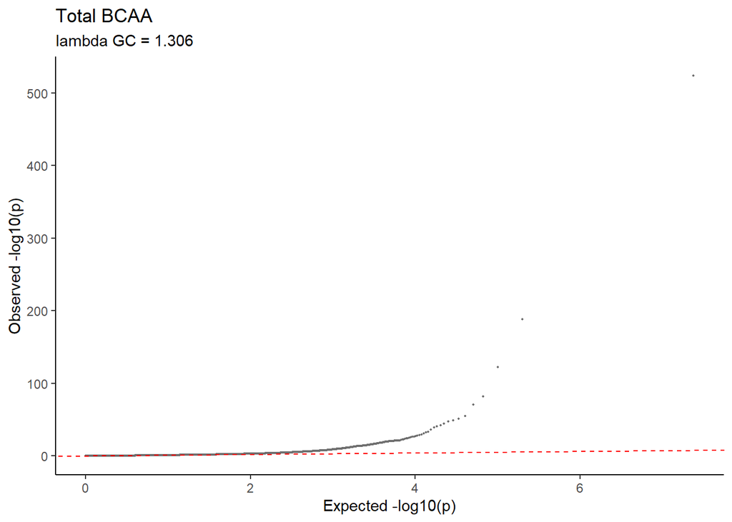

```r
# QQ plot
plot_qq(bcaa_meta.df, "Total BCAA")
```

```r
# heterogeneity summary (Cochran's Q)
bcaa_prop_het <- signif(mean(bcaa_meta.df$Q_pval<0.05,na.rm=TRUE),4)
# clear
rm(bcaa_meta.df)
```

```r
## Report Glucose

# lambda
glucose_lambda <- calc_lambda(glucose_meta.df)
cat(paste("Glucose: variants =", nrow(glucose_meta.df), "| lambda GC =", glucose_lambda))
```

```
Glucose: variants = 11946618 | lambda GC = 1.245
```

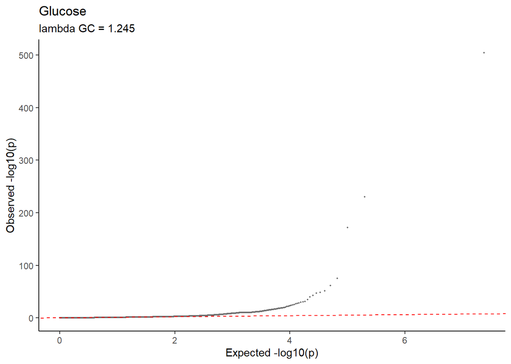

```r
# QQ plot
plot_qq(glucose_meta.df, "Glucose")
```

```r
# heterogeneity summary (Cochran's Q)
glucose_prop_het <- signif(mean(glucose_meta.df$Q_pval<0.05,na.rm=TRUE),4)
# clear
rm(glucose_meta.df)
```

**Summary of findings:**

The lambdaGC statistics were 1.306 and 1.245 for Total BCAA and Glucose respectively, indicating that genome-wide inflation was modest and consistent with polygenicity. QQ plots indicated adequate LD control without confounding. Cochran’s Q showed no systematic heterogeneity between cohorts for Total BCAA (0.05641) and Glucose (0.0567) respectively.

The pooled GWAS signal appeared to be reasonable and did not indicate significant confounding effects. This dataset can be used for downstream population statistics analyses to assess associations between metabolic traits Total BCAA and Glucose with disease trait Type 2 Diabetes.

## Genetic correlation and heritability analysis

Linkage disequilibrium was analyzed using `LDSC` via the command line. This step was restricted to SNPs in HapMap3 and included munging prior to linkage disequilibrium analysis.

```r
## Prepare summary stats for Linkage disequilibrium analysis

# Load HapMap3 SNP list
hm3 <- data.table::fread(paste0(getwd(),"/../data/w_hm3.snplist.gz"))

# fxn format for LDSC
prep_for_ldsc <- function(meta_path, out_path){
  meta.df <- data.table::fread(meta_path)
  # restrict to HapMap3 SNPs
  meta.df <- meta.df[rsid_est %in% hm3$SNP]
  # build LDSC input table
  ldsc.df <- data.frame(
    SNP = meta.df$rsid_est,               # rsID
    A1 = meta.df$effect_allele_est,       # effect allele
    A2 = meta.df$other_allele_est,        # other allele
    Z = meta.df$z_meta,                   # signed test statistic
    N = meta.df$n_est + meta.df$n_ukb,    # sample size
    P = pmax(10^(-meta.df$neglog10p_meta),1e-300))  # P value (capped min to avoid errors in LDSC)
  # write
  data.table::fwrite(ldsc.df, out_path, sep="\t")
  }

# prepare per trait LDSC input files
prep_for_ldsc(paste0(getwd(),"/../data/bcaa_meta.tsv.gz"),
              paste0(getwd(),"/../data/bcaa_ldsc.tsv"))
prep_for_ldsc(paste0(getwd(),"/../data/glucose_meta.tsv.gz"),
              paste0(getwd(),"/../data/glucose_ldsc.tsv"))

# clear
rm(hm3)
```

European linkage disequilibrium (LD) scores were obtained from the 1000 Genomes project in GRCh37. GWAS summary statistics for T2D were obtained from a Suzuki et al. (2024), which was a relatively recent European cohort study. The statistics were available in GRCh37, unlike those for Total BCAA and Glucose, which were available in the more recent GRCh38 genome build. In the T2D dataset, SNPs did not have rsIDs, and so their positions were mapped to rsIDs using LD scores data. This could then be used for linkage disequilibrium analysis using LDSC.

```r
## Prepare T2D GWAS summary stats for LDSC
# LD score for EUR population
ld_dir   <- paste0(getwd(),"/../data/eur_w_ld_chr/")

# map rsIDs for T2D
t2d_ldsc.df <- purrr::map_dfr(1:22, function(chr){
  message(paste("chromosome", chr))
  # ldscore map for current chr
  map.df <- data.table::fread(paste0(ld_dir, chr, ".l2.ldscore.gz"),
                              select=c("CHR","SNP","BP"))
  map.df <- data.table::as.data.table(map.df)
  map.df[, key := paste(CHR, BP, sep=":")]
  # lazy read per chr
  t2d.df <- arrow::open_dataset(paste0(getwd(),"/../data/t2d.parquet")) %>%
    dplyr::filter(Chromsome == chr) %>%
    dplyr::collect() %>%
    data.table::as.data.table()
  t2d.df[, key := paste(Chromsome, Position, sep=":")]
  # merge rsIDs
  t2d.df <- merge(t2d.df, map.df[, .(key, SNP)], by="key", all.x=TRUE)
  t2d.df <- t2d.df[!is.na(SNP)]
  # format output
  out <- data.frame(SNP=t2d.df$SNP,
                    A1=t2d.df$EffectAllele,
                    A2=t2d.df$NonEffectAllele,
                    Beta=t2d.df$Beta,
                    SE=t2d.df$SE,
                    P=t2d.df$Pval,
                    N=t2d.df$Neff)
  # clear
  rm(t2d.df, map.df)
  # return
  return(out)
})

# Check how many T2D variants mapped to rsID
print(paste("Total T2D variants mapped to rsID:", nrow(t2d_ldsc.df)))
```

```
[1] "Total T2D variants mapped to rsID: 1278208"
```

```r
# write T2D input for LDSC
data.table::fwrite(t2d_ldsc.df, paste0(getwd(),"/../data/t2d_ldsc.tsv"), sep="\t")
```

```bash
## LDSC prompts for command line

conda activate ldsc

# Munge
python munge_sumstats.py \
  --sumstats bcaa_ldsc.tsv \
  --out munged/bcaa \
  --merge-alleles w_hm3.snplist

python munge_sumstats.py \
  --sumstats glucose_ldsc.tsv \
  --out munged/glucose \
  --merge-alleles w_hm3.snplist

python munge_sumstats.py \
  --sumstats t2d_ldsc.tsv \
  --out munged/t2d \
  --merge-alleles w_hm3.snplist

# Heritability analysis
python ldsc.py \
  --h2 munged/bcaa.sumstats.gz \
  --ref-ld-chr eur_w_ld_chr/ \
  --w-ld-chr eur_w_ld_chr/ \
  --out results/bcaa_h2

python ldsc.py \
  --h2 munged/glucose.sumstats.gz \
  --ref-ld-chr eur_w_ld_chr/ \
  --w-ld-chr eur_w_ld_chr/ \
  --out results/glucose_h2

python ldsc.py \
  --h2 munged/t2d.sumstats.gz \
  --ref-ld-chr eur_w_ld_chr/ \
  --w-ld-chr eur_w_ld_chr/ \
  --out results/t2d_h2

# Genetic correlation
python ldsc.py \
  --rg munged/bcaa.sumstats.gz,munged/glucose.sumstats.gz \
  --ref-ld-chr eur_w_ld_chr/ \
  --w-ld-chr eur_w_ld_chr/ \
  --out results/bcaa_glucose_rg

python ldsc.py \
  --rg munged/bcaa.sumstats.gz,munged/t2d.sumstats.gz \
  --ref-ld-chr eur_w_ld_chr/ \
  --w-ld-chr eur_w_ld_chr/ \
  --out results/bcaa_t2d_rg

python ldsc.py \
  --rg munged/glucose.sumstats.gz,munged/t2d.sumstats.gz \
  --ref-ld-chr eur_w_ld_chr/ \
  --w-ld-chr eur_w_ld_chr/ \
  --out results/glucose_t2d_rg
```

```r
## Read LSDC outputs into R

# Heritability analysis
h2 <- map_dfr(list.files(path=paste0(getwd(),"/../results/ldsc"),
                         pattern="_h2\\.log$",
                         full.names = TRUE), \(f) {
                           x <- readLines(f)
                           v <- as.numeric(str_match(x[grep("Total Observed scale h2:", x)], "([0-9.]+) \\(([0-9.]+)\\)")[2:3])
                           tibble(trait = str_remove(basename(f),
                                                     "_h2\\.log$"), h2 = v[1], se = v[2])
                           })

# Genetic correlation
rg <- map_dfr(list.files(path=paste0(getwd(),"/../results/ldsc"),
                         pattern="_rg\\.log$",
                         full.names = TRUE), \(f) {
                           x <- readLines(f)
                           i <- grep("Summary of Genetic Correlation", x)
                           d <- str_split(str_trim(x[i + 2]), "\\s+")[[1]]
                           tibble(t1 = str_remove(basename(d[1]), "\\.sumstats\\.gz"),
                                  t2 = str_remove(basename(d[2]), "\\.sumstats\\.gz"),
                                  rg = as.numeric(d[3]), se = as.numeric(d[4]), p = as.numeric(d[6]))
                           })
```

Summary statistics and Heatmap

```r
## Table
h2 |>
  select(`Trait`=trait,`H^2`=h2,`h^2 (SE)`=se) |>
  flextable() |>
  autofit()
```

| Trait | H^2 | h^2 (SE) |
| --- | --- | --- |
| bcaa | 0.0654 | 0.0051 |
| glucose | 0.0506 | 0.0050 |
| t2d | 0.1379 | 0.0058 |

```r
## Table
rg |>
  mutate(across(c(t1,t2),toupper),
         `rg (SE)`=sprintf("%.3f (%.3f)",rg,se),
         P=formatC(p,format="e",digits=2)) |>
  select(`Trait 1`=t1,`Trait 2`=t2,`rg (SE)`,P) |>
  flextable() |>
  autofit()
```

| Trait 1 | Trait 2 | rg (SE) | P |
| --- | --- | --- | --- |
| BCAA | GLUCOSE | 0.229 (0.028) | 8.42e-16 |
| BCAA | T2D | 0.481 (0.027) | 3.17e-69 |
| GLUCOSE | T2D | 0.566 (0.038) | 8.28e-49 |

Heatmap showing pairwise genetic correlations. Color scale indicated directionality, while asterisks * indicated statistical significance.

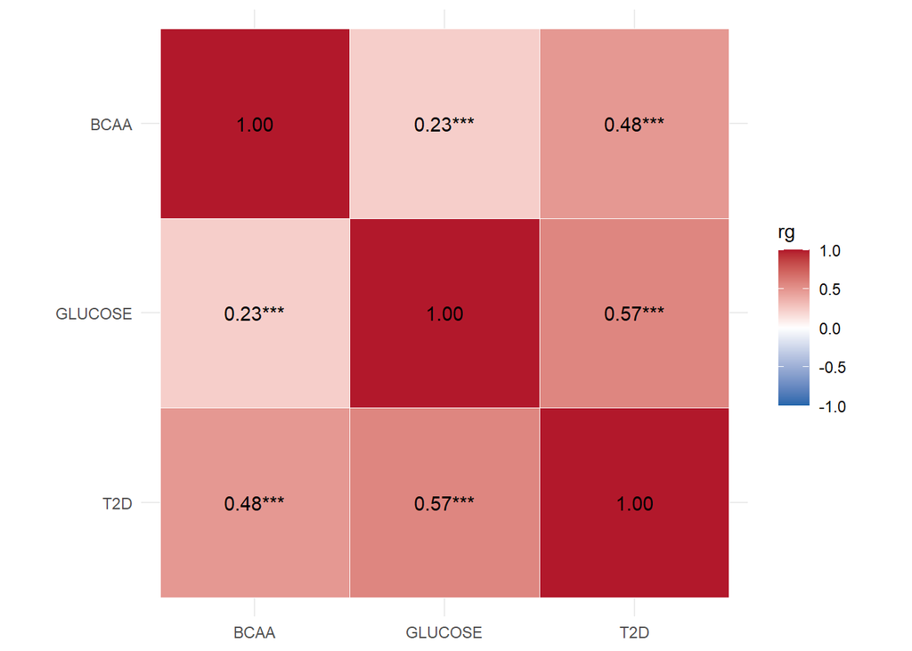

```r
## Heatmap showing genetic correlation

traits <- toupper(unique(c(rg$t1, rg$t2)))

# heatmap
rg |>
  transmute(t1 = toupper(t1), t2 = toupper(t2), rg, p) |>
  (\(d) bind_rows(d, rename(d, t1 = t2, t2 = t1),
                  tibble(t1 = traits, t2 = traits, rg = 1, p = NA)))() |>
  mutate(t1 = factor(t1, traits), t2 = factor(t2, rev(traits)),
         lab = ifelse(is.na(p), sprintf("%.2f", rg),
                      sprintf("%.2f%s", rg, c("", "*", "**", "***")[1 + (p < .05) + (p < .01) + (p < .001)]))) |>
  ggplot(aes(t1, t2, fill = rg)) +
  geom_tile(color = "white") +
  geom_text(aes(label = lab)) +
  scale_fill_gradient2(low = "#2166AC", high = "#B2182B", midpoint = 0, limits = c(-1, 1)) +
  coord_fixed() +
  labs(x = NULL, y = NULL) +
  theme_minimal()
```

**Summary of findings:**

Glucose shared the strongest positive genetic correlation (rg) with T2D at 0.57, as was expected of a positive control with significant shared biochemical pathways. Total BCAA shared substantial positive correlation with T2D at 0.48, indicating moderately shared genetic mechanisms. Total BCAA and Glucose had rg 0.23, indicating somewhat weak shared genetic mechanisms. Heritability (h^2) was modest for Total BCAA (0.065) and Glucose (0.051), and moderate for T2D (0.138).

## Identifying lead variants

Lead variants were identified using `PLINK` for clumping via the command line. LD Reference panel for European populations was obtained from 1000 Genomes project (`1kg.v3.tgz`).

```bash
## Clumping with PLINK

# load module
module load plink/1.9

# BCAA
plink \
  --bfile EUR \
  --clump bcaa_ldsc.tsv \
  --clump-snp-field SNP \
  --clump-field P \
  --clump-p1 5e-8 \
  --clump-p2 1e-5 \
  --clump-r2 0.001 \
  --clump-kb 10000 \
  --out leads/bcaa_lead

# Glucose
plink \
  --bfile EUR \
  --clump glucose_ldsc.tsv \
  --clump-snp-field SNP \
  --clump-field P \
  --clump-p1 5e-8 \
  --clump-p2 1e-5 \
  --clump-r2 0.001 \
  --clump-kb 10000 \
  --out leads/glucose_lead
```

Summary statistics and Manhattan plots

```r
## Load Lead variants analysis outputs from PLINK into R

# fxn to read PLINK clumping output
read_clumped <- function(f, trait_name){
  df <- data.table::fread(f)
  df <- df[, .(CHR, SNP, BP, P, TOTAL)]   # keep core columns
  df[, trait := trait_name]
  return(df[])
}
# read outputs
bcaa_leads    <- read_clumped(paste0(getwd(),"/../results/leads/bcaa_lead.clumped"),    "Total BCAA")
glucose_leads <- read_clumped(paste0(getwd(),"/../results/leads/glucose_lead.clumped"), "Glucose")
# leads
leads.df <- rbind(bcaa_leads, glucose_leads)
print(paste("BCAA lead variants:",    nrow(bcaa_leads)))
```

```
[1] "BCAA lead variants: 146"
```

```r
print(paste("Glucose lead variants:", nrow(glucose_leads)))
```

```
[1] "Glucose lead variants: 120"
```

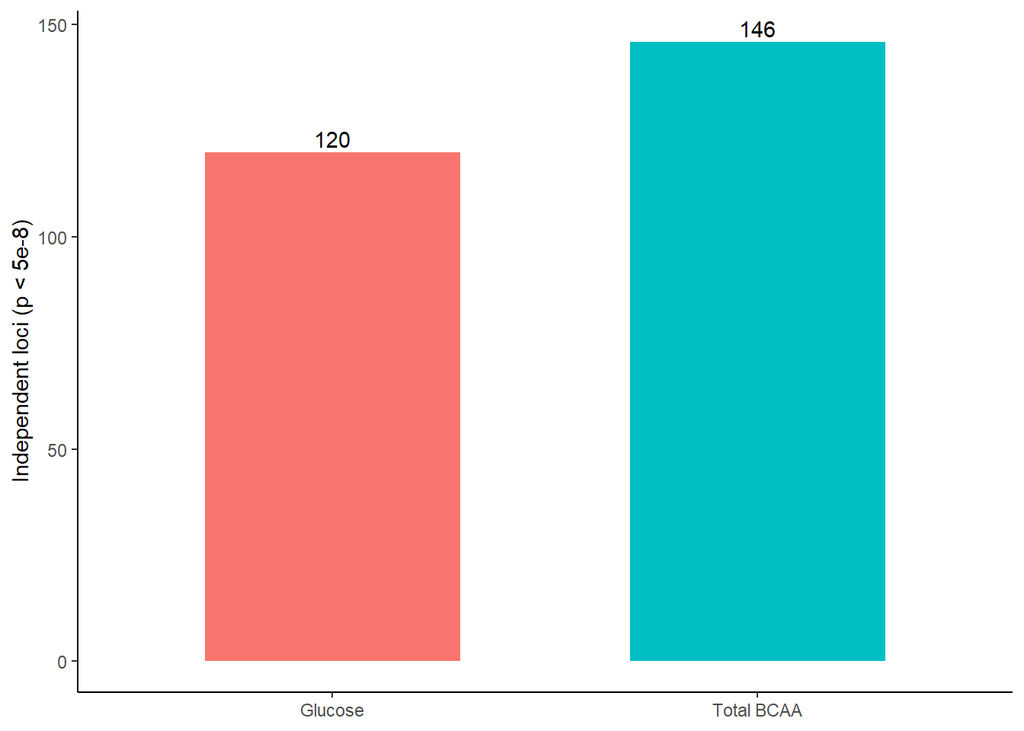

```r
## Visualize counts of lead variants from each trait

# bar plot
leads.df |>
  dplyr::count(trait, name = "n_loci") |>
  ggplot(aes(reorder(trait, n_loci), n_loci, fill = trait)) +
  geom_col(width = 0.6, show.legend = FALSE) +
  geom_text(aes(label = n_loci), vjust = -0.3) +
  labs(x = NULL, y = "Independent loci (p < 5e-8)") +
  theme_classic()
```

Top 10 most significant leads for each trait were shown in the table below.

```r
## Table showing top 10 significant leads for each trait

leads.df |>
  dplyr::group_by(trait) |>
  dplyr::slice_min(P, n=10, with_ties=FALSE) |>
  dplyr::ungroup() |>
  dplyr::mutate(P = formatC(P, format = "e", digits = 2)) |>
  dplyr::select(Trait = trait, SNP, CHR, BP, `Clumped SNPs` = TOTAL, P) |>
  dplyr::arrange(Trait, CHR, BP) |>
  flextable() |>
  autofit()
```

| Trait | SNP | CHR | BP | Clumped SNPs | P |
| --- | --- | --- | --- | --- | --- |
| Glucose | rs573225 | 2 | 169,757,541 | 4,187 | 1.00e-300 |
| Glucose | rs11708067 | 3 | 123,065,778 | 4,336 | 6.49e-73 |
| Glucose | rs1604038 | 3 | 170,709,193 | 3,727 | 1.01e-75 |
| Glucose | rs10244051 | 7 | 15,063,833 | 5,314 | 1.35e-50 |
| Glucose | rs2908277 | 7 | 44,183,433 | 2,383 | 4.84e-41 |
| Glucose | rs1004558 | 7 | 44,240,407 | 4,586 | 8.85e-174 |
| Glucose | rs3802177 | 8 | 118,185,025 | 4,209 | 4.55e-60 |
| Glucose | rs11251694 | 10 | 3,114,645 | 2,019 | 4.93e-55 |
| Glucose | rs2388595 | 10 | 3,138,009 | 3,846 | 5.54e-111 |
| Glucose | rs7903146 | 10 | 114,758,349 | 4,676 | 8.16e-84 |
| Total BCAA | rs1260326 | 2 | 27,730,940 | 4,876 | 1.39e-188 |
| Total BCAA | rs10211524 | 2 | 65,208,074 | 4,258 | 5.76e-114 |
| Total BCAA | rs1128249 | 2 | 165,528,624 | 3,871 | 9.37e-42 |
| Total BCAA | rs2943645 | 2 | 227,099,180 | 4,782 | 2.78e-46 |
| Total BCAA | rs7658173 | 4 | 89,182,518 | 3,760 | 1.00e-300 |
| Total BCAA | rs12641788 | 4 | 89,222,164 | 1,931 | 1.61e-48 |
| Total BCAA | rs2657879 | 12 | 56,865,338 | 4,502 | 7.13e-72 |
| Total BCAA | rs12149660 | 16 | 70,309,237 | 4,569 | 1.13e-184 |
| Total BCAA | rs17732541 | 17 | 7,203,350 | 4,320 | 1.88e-51 |
| Total BCAA | rs4801775 | 19 | 49,304,059 | 4,156 | 2.35e-54 |

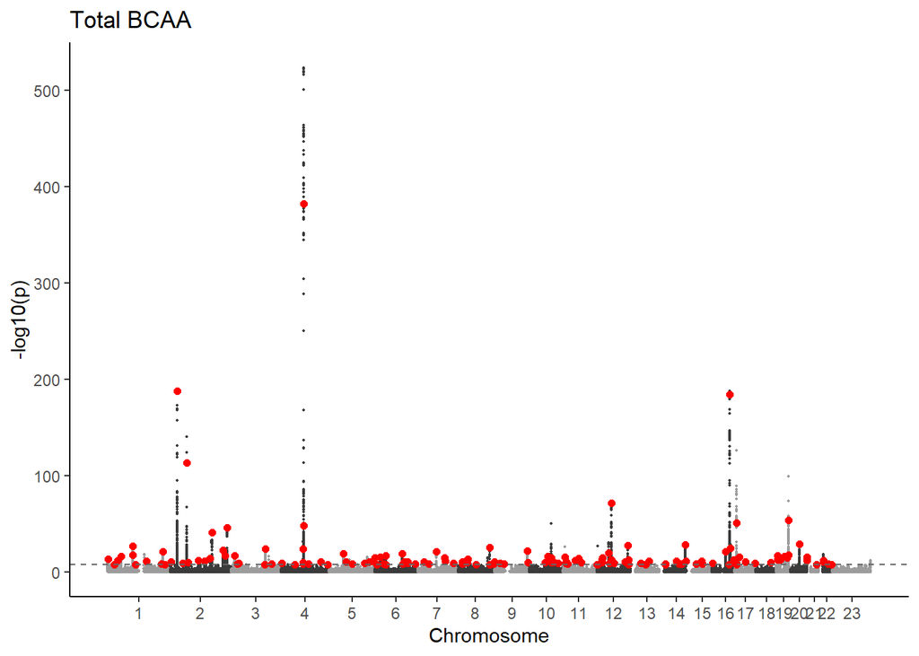

```r
## Manhattan plot with lead variants highlighted

# fxn to generate Manhattan plot
make_manhattan <- function(meta_path, leads, trait_name){
  # select relevant columns
  df <- data.table::fread(meta_path,
                          select = c("rsid_est","chromosome_est","base_pair_location_est","neglog10p_meta")) |>
    data.table::as.data.table()
  data.table::setnames(df,
                       c("chromosome_est","base_pair_location_est"),
                       c("chr_est","pos_est"))
  sig <- df$neglog10p_meta > 5
  df  <- rbind(df[sig], df[!sig][seq(1, .N, by = 50)])

  data.table::setorder(df, chr_est, pos_est)
  chr_len <- df[, .(chr_max = max(pos_est)), by = chr_est]
  chr_len[, chr_add := data.table::shift(cumsum(as.numeric(chr_max)), fill = 0)]
  df <- merge(df, chr_len[, .(chr_est, chr_add)], by = "chr_est")
  df[, bp_cum := pos_est + chr_add]
  axis_df <- df[, .(center = mean(bp_cum)), by = chr_est]
  df[, is_lead := rsid_est %in% leads$SNP]
  # plot
  p <- ggplot(df, aes(bp_cum, neglog10p_meta)) +
    geom_point(aes(color = factor(chr_est %% 2)), size = 0.4) +
    geom_point(data = df[is_lead == TRUE], color = "red", size = 1.6) +
    geom_hline(yintercept = -log10(5e-8), linetype = "dashed", color = "grey40") +
    scale_color_manual(values = c("#3B3B3B", "#9C9C9C"), guide = "none") +
    scale_x_continuous(labels = axis_df$chr_est, breaks = axis_df$center) +
    labs(title = trait_name, x = "Chromosome", y = "-log10(p)") +
    theme_classic() +
    theme(panel.grid = element_blank())
  rm(df); gc()
  return(p)
}

# make plots
make_manhattan(paste0(getwd(),"/../data/bcaa_meta.tsv.gz"),
               bcaa_leads,"Total BCAA")
```

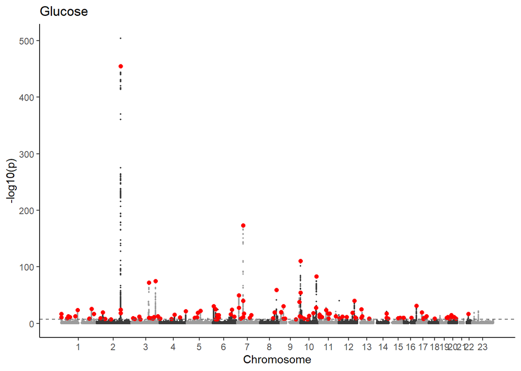

```r
make_manhattan(paste0(getwd(),"/../data/glucose_meta.tsv.gz"),
               glucose_leads,"Glucose")
```

**Summary of findings:**

LD-based clumping identified 146 independent lead variants associated with Total BCAA and 120 independent lead variants associated with Glucose at genome-wide significance.

This indicates that both BCAA and Glucose were highly polygenic with many independent loci across the genome contributing to trait variation.

## Fine-mapping and missense variants

Fine-mapping was conducted using `PLINK`, `susieR` and `VEP`. This portion of the analysis focused on loci surrounding lead variants obtained from Step 3: **rs1260326** for **BCAA** and **rs2908277** for **Glucose**.

```r
## Convert BCAA & Glucose meta files to parquet for lazy reading
for(trait in c("bcaa","glucose")){
  pq <- paste0(getwd(),"/../data/",trait,"_meta.parquet")
  if(!file.exists(pq)){
    arrow::write_parquet(data.table::fread(paste0(getwd(),"/../data/",trait,"_meta.tsv.gz")), pq)
  }
}
```

Summary statistics and PIP plots

```r
## Prepare PLINK inputs

# fxn to extract +/- 500 kb region around lead SNPs
extract_region <- function(trait, chr, pos, out_snps, window=5e5){
  reg <- arrow::open_dataset(paste0(getwd(),"/../data/",trait,"_meta.parquet")) %>%
    dplyr::select(rsid_est, chromosome_est, base_pair_location_est,
                  effect_allele_est, other_allele_est, z_meta, n_est,
                  n_ukb) %>%
    dplyr::filter(chromosome_est == chr,
                  base_pair_location_est >= pos-window,
                  base_pair_location_est <= pos+window) %>%
    dplyr::collect() %>%
    data.table::as.data.table()
  reg[, N := n_est + n_ukb]   # total sample size
  data.table::fwrite(reg[, .(rsid_est)], out_snps, col.names=FALSE)
  print(paste("SNPs in",trait,"region:", nrow(reg)))
  return(reg[])
}

# Extract SNPs: BCAA (rs1260326), Glucose (rs2908277)
bcaa_region    <- extract_region("bcaa",chr=2,pos=27730940,
                                 out_snps=paste0(getwd(),"/../data/bcaa_snps.txt"))
```

```
[1] "SNPs in bcaa region: 2720"
```

```r
glucose_region <- extract_region("glucose", chr=7, pos=44183433,
                                 out_snps=paste0(getwd(),"/../data/glucose_snps.txt"))
```

```
[1] "SNPs in glucose region: 3472"
```

```bash
## bash code for PLINK

module load plink/1.9

plink --bfile EUR --extract bcaa_snps.txt \
  --r square --write-snplist --out bcaa_ld

plink --bfile EUR --extract glucose_snps.txt \
  --r square --write-snplist --out glucose_ld
```

```r
## Fine-mapping was conducted with susie

# panel alleles
bim <- data.table::fread(paste0(getwd(),"/../results/plink/EUR.bim"),
                         select=c(2,5,6),
                         col.names=c("rsid","A1_panel","A2_panel"))

# fxn to run susie on selected locus
run_susie <- function(region, ld_prefix, trait){
  # load data
  snps <- readLines(paste0(getwd(),"/../results/plink/",ld_prefix,".snplist"))
  R <- as.matrix(data.table::fread(paste0(getwd(),"/../results/plink/",ld_prefix,".ld")))
  dimnames(R) <- list(snps, snps)
  # keep SNPs in both, order by LD
  reg <- region[match(snps, rsid_est)][!is.na(rsid_est)]
  R   <- R[reg$rsid_est, reg$rsid_est]
  # harmonize
  reg <- merge(reg, bim, by.x="rsid_est", by.y="rsid", sort=FALSE)
  reg <- reg[match(colnames(R), rsid_est)]
  z <- reg$z_meta
  z[reg$effect_allele_est != reg$A1_panel] <- -z[reg$effect_allele_est != reg$A1_panel]
  # fit
  fit <- susie_rss(z=z, R=R, n=round(mean(reg$N)), L=1)
  reg[, pip := susie_get_pip(fit)]
  reg[, trait := trait]
  # report credible sets
  #print(paste0(trait, " credible sets:"))
  #print(susie_get_cs(fit, Xcorr=R))
  rm(R)
  return(list(fit=fit, reg=reg[]))
}

# fine-map both loci
bcaa_fm <- run_susie(bcaa_region, "bcaa_ld", "Total BCAA")
glucose_fm <- run_susie(glucose_region, "glucose_ld", "Glucose")
```

```r
## Prepare VEP input

# build VEP input from credible-set variants
bcaa_cs <- bcaa_fm$reg[order(-pip)][1:5, .(rsid_est, chromosome_est,base_pair_location_est,effect_allele_est,other_allele_est,pip)]
glucose_cs <- glucose_fm$reg[order(-pip)][1:10, .(rsid_est, chromosome_est, base_pair_location_est, effect_allele_est, other_allele_est, pip)]

# Combine + format for VEP
cs <- rbind(bcaa_cs, glucose_cs)
vep_in <- cs[, .(chromosome_est, base_pair_location_est, base_pair_location_est,
                 paste0(other_allele_est,"/",effect_allele_est),"+",rsid_est)]

# write
data.table::fwrite(vep_in, paste0(getwd(),"/../data/cs_variants.txt"),
                   sep="\t", col.names=FALSE)
```

```bash
## Run VEP on command line

module load vep/101

vep \
  --offline \
  --cache \
  --dir_cache ../../../references \
  --cache_version 101 \
  --assembly GRCh38 \
  --input_file cs_variants.txt \
  --output_file cs_vep.txt \
  --symbol \
  --canonical \
  --force_overwrite
```

```r
## Read VEP outputs into R, annotate credible sets

# read VEP output, extract relevant data
vep <- data.table::fread(paste0(getwd(),"/../results/vep/cs_vep.txt"),
                         skip="#Uploaded_variation")
vep <- vep[, .(rsid_est=`#Uploaded_variation`,Consequence,
               SYMBOL=sub(".*SYMBOL=([^;]+).*", "\\1", Extra))]
vep <- unique(vep,by="rsid_est")
vep[,missense:=grepl("missense",Consequence,ignore.case=TRUE)]

# credible-set variants + PIPs from both loci
cs <- rbind(
  bcaa_fm$reg[order(-pip)][1:5, .(trait="Total BCAA",rsid_est,base_pair_location_est,pip)],
  glucose_fm$reg[order(-pip)][1:10, .(trait="Glucose",rsid_est,base_pair_location_est,pip)])

# join annotation
cs_annot <- merge(cs,vep,by="rsid_est",all.x=TRUE)
data.table::setorder(cs_annot,trait,-pip)
```

```r
## Display key results

# Table
cs_annot |>
  dplyr::mutate(PIP = round(pip, 3),
                Missense = ifelse(missense, "Yes", "No")) |>
  dplyr::select(Trait = trait, SNP = rsid_est, BP = base_pair_location_est,
                Gene = SYMBOL, Consequence, PIP, Missense) |>
  flextable() |>
  autofit()
```

| Trait | SNP | BP | Gene | Consequence | PIP | Missense |
| --- | --- | --- | --- | --- | --- | --- |
| Glucose | rs2908286 | 44,195,138 | GCK | intron_variant,non_coding_transcript_variant | 0.226 | No |
| Glucose | rs2971670 | 44,186,502 | GCK | intron_variant | 0.186 | No |
| Glucose | rs1985469 | 44,200,725 | YKT6 | upstream_gene_variant | 0.141 | No |
| Glucose | rs1004558 | 44,200,808 | YKT6 | upstream_gene_variant | 0.104 | No |
| Glucose | rs741037 | 44,193,234 | GCK | upstream_gene_variant | 0.098 | No |
| Glucose | rs2908289 | 44,184,343 | GCK | intron_variant | 0.078 | No |
| Glucose | rs1799884 | 44,189,469 | GCK | upstream_gene_variant | 0.066 | No |
| Glucose | rs730497 | 44,184,122 | GCK | intron_variant | 0.037 | No |
| Glucose | rs6975024 | 44,192,287 | GCK | upstream_gene_variant | 0.034 | No |
| Glucose | rs2971667 | 44,205,461 | YKT6 | intron_variant | 0.011 | No |
| Total BCAA | rs1260326 | 27,508,073 | GCKR | missense_variant,splice_region_variant | 1.000 | Yes |
| Total BCAA | rs4665972 | 27,375,230 | SNX17 | intron_variant | 0.000 | No |
| Total BCAA | rs13399758 | 27,232,858 | CAD | intron_variant | 0.000 | No |
| Total BCAA | rs6747264 | 27,232,413 | CAD | intron_variant | 0.000 | No |
| Total BCAA | rs73921482 | 27,231,770 | CAD | intron_variant | 0.000 | No |

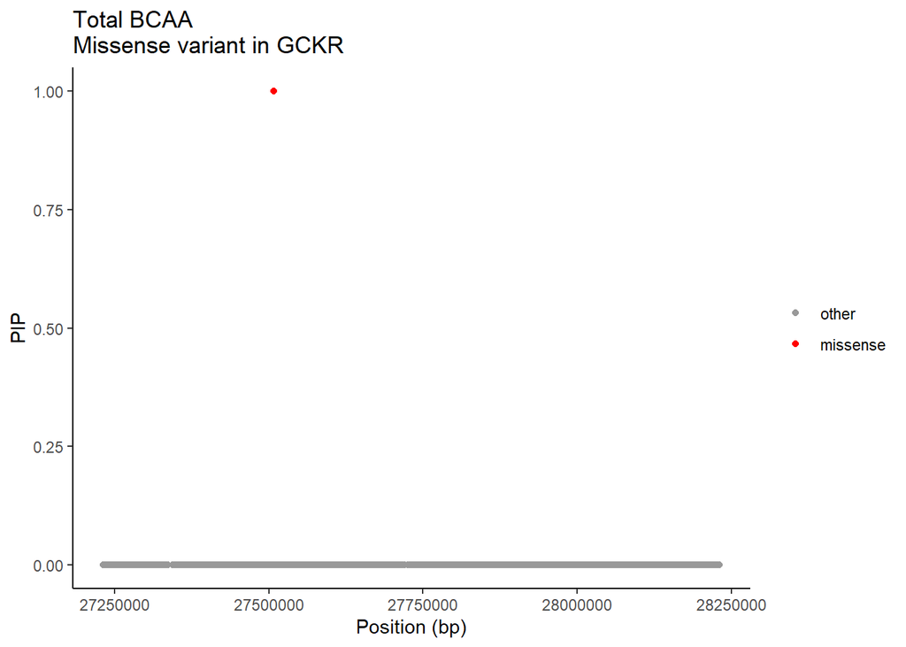

```r
## PIP plot

# fxn for regional PIP plot, highlight missense variants
plot_pip <- function(fm, trait_name){
  d <- fm$reg
  d[, missense := rsid_est %in% vep[missense==TRUE]$rsid_est]
  ggplot(d, aes(base_pair_location_est, pip)) +
    geom_point(aes(color=missense), size=1.5) +
    scale_color_manual(values=c("FALSE"="grey60","TRUE"="red"),
                       labels=c("other","missense"), name=NULL) +
    labs(title=trait_name, x="Position (bp)", y="PIP") +
    theme_classic()
}

# make plots
plot_pip(bcaa_fm, "Total BCAA \nMissense variant in GCKR")
```

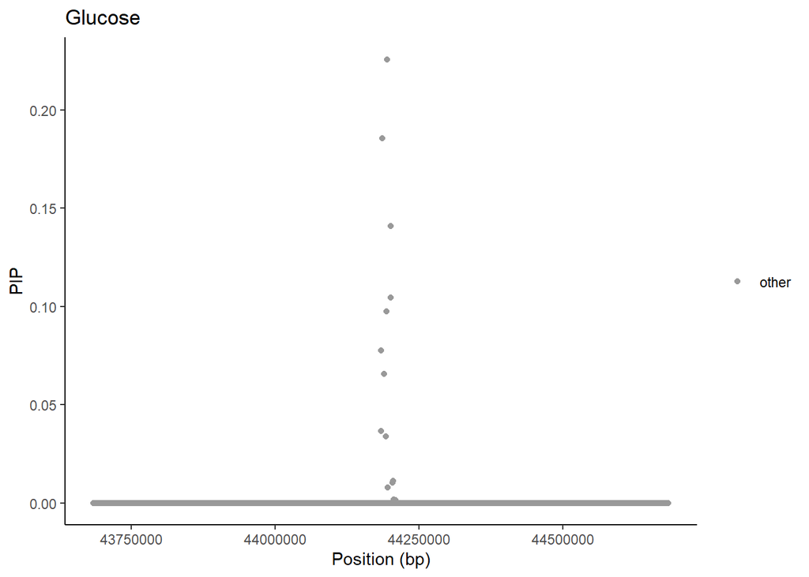

```r
plot_pip(glucose_fm, "Glucose")
```

## Colocalization with molecular QTLs

Colocalization was conducted for Total BCAA using eQTL datasets obtained from eQTL Catalogue API and `coloc` in `R`.

Initially SNP rs1260326 was selected for colocalization analysis, since it was found to have a missense variant in the BCAA analysis. This gene could not be found in three different eQTL datasets (GTEx blood, Lepik_2017 blood, GTEx liver), after which I decided to use an eQTL found within nearby gene SLC5A6, which could be found in the Lepik_2017 blood dataset. Blood was selected as the tissue since Estonian and UK Biobank data was based on blood samples.

Posterior probabilities and Regional association plots

```r
## Posterior probabilities (BCAA vs SLC5A6 eQTL)

# Table
data.frame(
  Hypothesis = c("H0 (no assoc)","H1 (GWAS only)","H2 (eQTL only)",
                 "H3 (distinct variants)","H4 (shared variant)"),
  PP = formatC(as.numeric(res$summary[2:6]),format="g",digits=3)) |>
  flextable() |>
  autofit()
```

| Hypothesis | PP |
| --- | --- |
| H0 (no assoc) | 1.25e-74 |
| H1 (GWAS only) | 1.4e-14 |
| H2 (eQTL only) | 8.94e-61 |
| H3 (distinct variants) | 1 |
| H4 (shared variant) | 2.15e-12 |

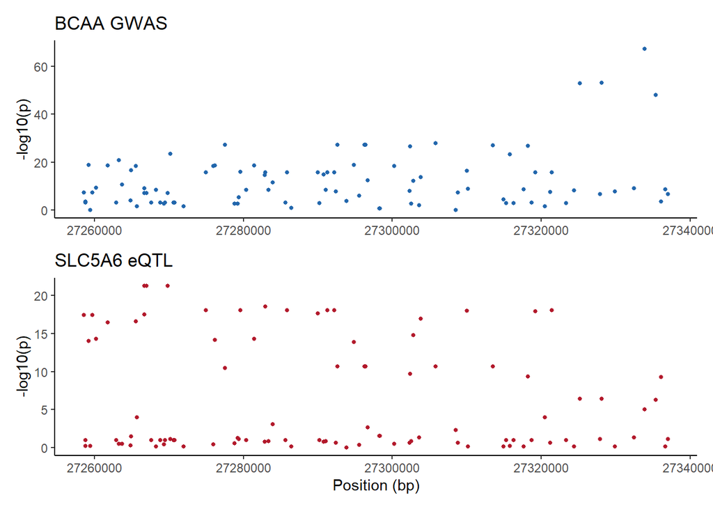

```r
## Scatterplots showing GWAS

# GWAS -log10p from z = beta/se
g[, neglog10p := -log10(2*pnorm(-abs(beta_meta/se_meta)))]

p1 <- ggplot(g, aes(base_pair_location_est, neglog10p)) +
  geom_point(size=1, color="#2166AC") +
  labs(title="BCAA GWAS", x=NULL, y="-log10(p)") +
  theme_classic()

p2 <- ggplot(e, aes(position, nlog10p)) +
  geom_point(size=1, color="#B2182B") +
  labs(title="SLC5A6 eQTL", x="Position (bp)", y="-log10(p)") +
  theme_classic()

p1 / p2
```

**Summary of findings:**

The BCAA signal and SLC5A6 eQTL were driven by distinct causal variants (PP.H3=1.0; PP.H4=2.15e-12), meaning that BCAA association with the locus was not mediated by SLC5A6 expression. This means that the BCAA signal and the SLC5A6 eQTL are driven by separate causal variants.

## Genome-wide Mendelian randomization

Genome-wide mendelian randomization was carried out using `MendelianRandomization` in `R` and IVW (random effects, delta weights). Sensitivity analysis was conducted using `Egger` to test for pleiotropy. This analysis was conducted for the metabolite Total BCAA and T2D as outcome

```r
## Mendelian randomization with BCAA

# instrument list
if(!exists("bcaa_leads")){
  bcaa_leads <- fread(paste0(getwd(),"/../results/leads/bcaa_lead.clumped"))[, .(SNP)]
}

# exposure: BCAA effects for lead SNPs
exp <- arrow::open_dataset(paste0(getwd(),"/../data/bcaa_meta.parquet")) %>%
  dplyr::filter(rsid_est %in% bcaa_leads$SNP) %>%
  dplyr::select(rsid_est, effect_allele_est, other_allele_est, beta_meta, se_meta) %>%
  dplyr::collect() %>% as.data.table()

# outcome: T2D effects
out <- fread(paste0(getwd(),"/../data/t2d_ldsc.tsv"),
             select=c("SNP","A1","A2","Beta","SE"))[SNP %in% exp$rsid_est]

# merge + harmonize
mr <- merge(exp, out, by.x="rsid_est", by.y="SNP")
flip <- mr$effect_allele_est == mr$A2 & mr$other_allele_est == mr$A1
mr[flip, Beta := -Beta]
mr <- mr[(effect_allele_est==A1 & other_allele_est==A2) | flip]

# sign-align
s <- sign(mr$beta_meta)
mr[,`:=`(beta_exposure=beta_meta,
         se_exposure=se_meta,
         beta_outcome=Beta,
         se_outcome=SE)]

rm(exp,out)
print(paste("MR instruments:",nrow(mr)))
```

```
[1] "MR instruments: 146"
```

```r
## Display key findings

MRin <- mr_input(exposure="Total BCAA", outcome="T2D",
                 bx=mr$beta_exposure, bxse=mr$se_exposure,
                 by=mr$beta_outcome,  byse=mr$se_outcome,
                 snps=mr$rsid_est)
ivw <- mr_ivw(MRin, alpha=0.05, weights="delta", model="random")

#data.frame(Method="IVW (random)",
#           Estimate=signif(ivw@Estimate,3),
#           SE=signif(ivw@StdError,3),
#           CI=paste0("(",signif(ivw@CILower,3),", ",signif(ivw@CIUpper,3),")"),
#           P=signif(ivw@Pvalue,3),
#           nSNP=ivw@SNPs) |>
#  flextable() |> autofit()
```

Summary statistics and Mendelian Randomization scatter plot

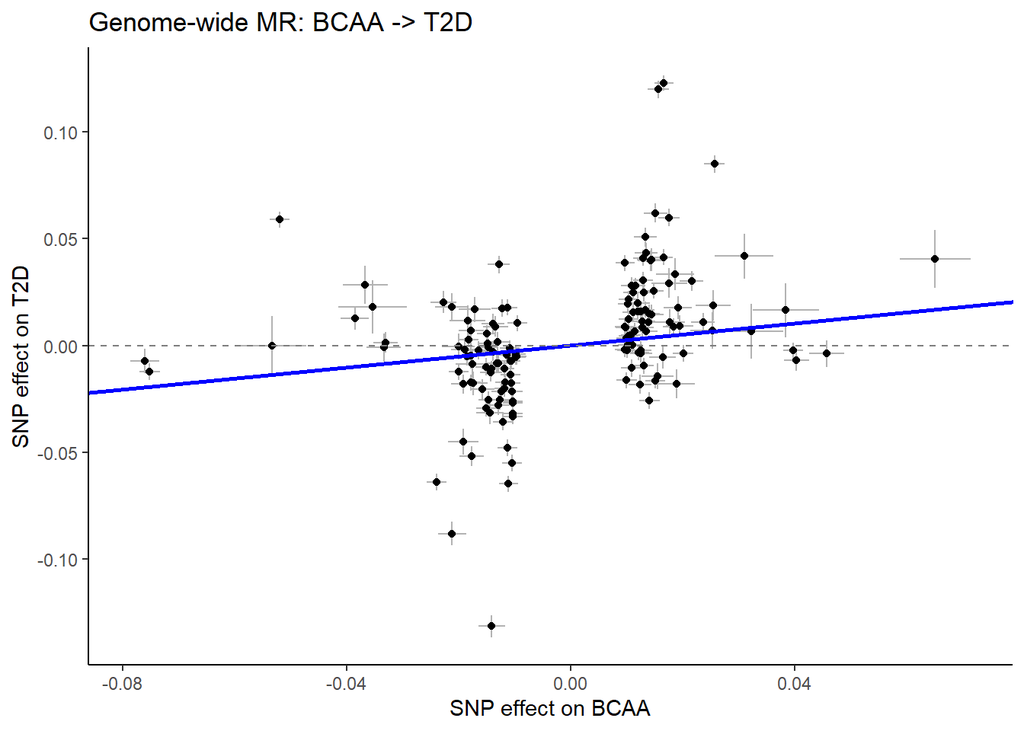

```r
## Plot

ggplot(mr, aes(beta_exposure, beta_outcome)) +
  geom_errorbar(aes(ymin=beta_outcome-se_outcome, ymax=beta_outcome+se_outcome),
                color="grey70", width=0) +
  geom_errorbarh(aes(xmin=beta_exposure-se_exposure, xmax=beta_exposure+se_exposure),
                 color="grey70", height=0) +
  geom_point(size=1.5) +
  geom_abline(slope=ivw@Estimate, intercept=0, color="blue", linewidth=1) +
  geom_hline(yintercept=0, linetype="dashed", color="grey50") +
  labs(title="Genome-wide MR: BCAA -> T2D",
       x="SNP effect on BCAA", y="SNP effect on T2D") +
  theme_classic()
```

```r
# MR sensitivity analysis using Egger

# run sensitivity methods
egger <- mr_egger(MRin)

# compare all three methods + Egger pleiotropy intercept
data.frame(
  Method = c("IVW (random)","MR-Egger"),
  Estimate = signif(c(ivw@Estimate,egger@Estimate),3),
  SE = signif(c(ivw@StdError,egger@StdError.Est),3),
  P = signif(c(ivw@Pvalue,egger@Pvalue.Est),3)) |>
  flextable() |>
  add_footer_lines(paste0("MR-Egger intercept = ",signif(egger@Intercept,4)," (p = ", signif(egger@Pvalue.Int,3), ")")) |>
  autofit()
```

| Method | Estimate | SE | P |
| --- | --- | --- | --- |
| IVW (random) | 0.258 | 0.0811 | 0.00149 |
| MR-Egger | -0.298 | 0.2340 | 0.20300 |

MR-Egger intercept = 0.01988 (p = 3.9e-06)

**Summary of findings:**

Genome-wide MR using 146 independent instruments produced a significant positive IVW estimate for the effect of Total BCAA on T2D (Beta=0.26, p=1.49e-3). However, MR-Egger indicated strong directional pleiotropy (intercept=1.98e-2, p=3.9e-6) with a non-significant and directionally opposite slope (Beta=-0.30, p=0.20). The significant IVW estimate was possibly biased by pleiotropy among metabolite instruments and the causal effect of BCAA on T2D was inconclusive at this stage.

The significant IVW estimate is possibly confounded by pleiotropy, and so a causal role for BCAAs in T2D cannot be established from this analysis. It is possible for Total BCAA to result from metabolic dysfunction instead of causing it.

## Cis-Mendelian randomization

While Genome-wide MR conducted in the previous step was pleiotropy-prone, cis-MR only instruments at the causal gene, drastically reducing pleiotropy and resulting in a cleaner estimate. This step was carried out using `MendelianRandomization` and Wald ratio as the test statistic.

This analysis was conducted for **Total BCAA** and **T2D**, and centered around the **rs1260326** locus in gene GCKR.

```r
## cis-MR GCKR (BCAA -> T2D)

# cis-region BCAA instruments (GCKR +/-200kb, MAF>1%, p<5e-8)
cis <- arrow::open_dataset(paste0(getwd(),"/../data/bcaa_meta.parquet")) %>%
  dplyr::filter(chromosome_est==2,
                base_pair_location_est>=27508073-200000,
                base_pair_location_est<=27508073+200000,
                neglog10p_meta>-log10(5e-8)) %>%
  dplyr::select(rsid_est,base_pair_location_est,effect_allele_est, other_allele_est,
                beta_meta,se_meta,effect_allele_frequency_est, neglog10p_meta) %>%
  dplyr::collect() %>% as.data.table()
cis <- cis[effect_allele_frequency_est %between% c(0.01,0.99)]

# prune
setorder(cis, -neglog10p_meta)
keep <- character(0)
pool <- copy(cis)
while(nrow(pool) > 0){
  top <- pool[1]
  keep <- c(keep, top$rsid_est)
  pool <- pool[abs(base_pair_location_est-top$base_pair_location_est)>1e5]
  }
ins <- cis[rsid_est %in% keep]

# T2D effects + harmonize
out <- fread(paste0(getwd(),"/../data/t2d_ldsc.tsv"),
             select=c("SNP","A1","A2","Beta","SE"))[SNP %in% ins$rsid_est]
mr <- merge(ins, out, by.x="rsid_est", by.y="SNP")
flip <- mr$effect_allele_est == mr$A2 & mr$other_allele_est == mr$A1
mr[flip, Beta := -Beta]
mr <- mr[(effect_allele_est==A1 & other_allele_est==A2)|flip]
s <- sign(mr$beta_meta)
mr[,`:=`(beta_exposure=beta_meta,
         se_exposure=se_meta,
         beta_outcome=Beta,
         se_outcome=SE)]

# cis-MR: IVW if >=2 instruments, else Wald ratio
if(nrow(mr)>=2){
  MRin<-mr_input(exposure="Total BCAA",outcome="T2D",
                 bx=mr$beta_exposure,bxse=mr$se_exposure,
                 by=mr$beta_outcome,byse=mr$se_outcome,snps=mr$rsid_est)
  cis_res <- mr_ivw(MRin,alpha=0.05,weights="delta",model="random")
}

print(paste("cis instruments:", nrow(mr)))
```

```
[1] "cis instruments: 1"
```

Since there was 1 independent signal in this region, a Wald ratio test was selected as the test statistic.

Summary statistics and Mendelian Randomization scatter plot

```r
## Wald ratio test
wald_est <- mr$beta_outcome/mr$beta_exposure
wald_se <- sqrt(mr$se_outcome^2/mr$beta_exposure^2 +
                  (mr$beta_outcome^2 * mr$se_exposure^2)/mr$beta_exposure^4)
wald_p <- 2*pnorm(-abs(wald_est/wald_se))

data.frame(Method="Wald ratio (cis)",
           Gene="GCKR",
           SNP=mr$rsid_est,
           Estimate=signif(wald_est,3),
           SE=formatC(wald_se,format="e",digits=2),
           P=formatC(wald_p,format="e",digits=2)) |>
  flextable() |> autofit()
```

| Method | Gene | SNP | Estimate | SE | P |
| --- | --- | --- | --- | --- | --- |
| Wald ratio (cis) | GCKR | rs1260326 | -1.13 | 8.28e-02 | 1.30e-42 |

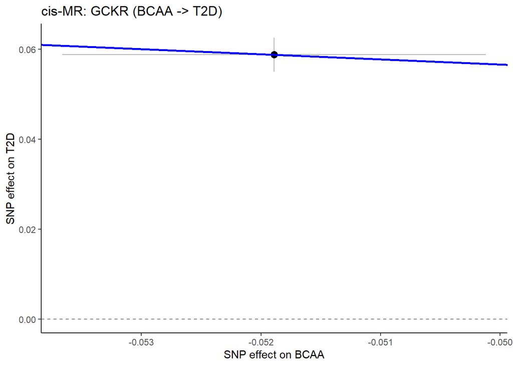

```r
## Plot

ggplot(mr,aes(beta_exposure,beta_outcome)) +
  geom_errorbar(aes(ymin=beta_outcome-se_outcome,
                    ymax=beta_outcome+se_outcome),
                color="grey70",width=0) +
  geom_errorbarh(aes(xmin=beta_exposure-se_exposure,
                     xmax=beta_exposure+se_exposure),
                 color="grey70",height=0) +
  geom_point(size=3) +
  geom_abline(slope=mr$beta_outcome/mr$beta_exposure,intercept=0,
              color="blue",linewidth=1) +
  geom_hline(yintercept=0,linetype="dashed",color="grey50") +
  labs(title="cis-MR: GCKR (BCAA -> T2D)",
       x="SNP effect on BCAA",y="SNP effect on T2D") +
  theme_classic()
```

**Summary of findings:**

Cis-Mendelian Randomization at gene GCKR, instrumented by SNP rs1260326, produced a significant negative Wald-ratio estimate for effect of BCAA levels on T2D (Beta=-1.13, p=1.3e-42, instrument F=850). Based on this result, the selected variant in GCKR gene appeared to have directionally opposing associations with BCAA levels and T2D.

## Citations

Tambets, R., Jesse, M., Kronberg, J. et al. Genetic analysis of circulating metabolic traits in 619,372 individuals. Nature 655, 971–978 (2026). https://doi.org/10.1038/s41586-026-10532-5